# The importance of a script

> 1. Permanent
> 2. Repeatable
> 3. Annotated
> 4. Shareable

### Practice: We will do this exercise together…

## Step 1

```
File --> New File --> R Script or Top left green and white plus sign drop down then select R Script
```

## Step 2

```
The # symbols declares that anything after it is a comment

You should start with some information at the top, for example:
#############################
## Author:                ###
## Date:                  ###
## Purpose:               ###
#############################
```

## Step 3

Leave an empty “blank line” - These are important to create chunks of code and annotation

## Step 4

Next **if** your script has code that is standalone and independent, we recomend you always start a script by clearing R’s brain `rm(list=ls())`

**If** your script is a function or group of functions to be sourced by another script, skip this step!!

Try typing the `rm` function instead of copy pasting it. You will notice Rstudio **closes brackets** for you automatically

## Step 5

Leave another empty “blank line”

## Step 6

### Now you are ready to start writing your first script! Copy paste the code inside the `[]` Then move to Step 7

We will go over how to construct these functions in the next module

A loop

```r
 for(i in 1:10){ # for loop run from 1 to 10
print("Darwin rules!") # write a sentence 10 times
print(i*i) # also print each number multiplied by itself
}
```

```
## [1] "Darwin rules!"
## [1] 1
## [1] "Darwin rules!"
## [1] 4
## [1] "Darwin rules!"
## [1] 9
## [1] "Darwin rules!"
## [1] 16
## [1] "Darwin rules!"
## [1] 25
## [1] "Darwin rules!"
## [1] 36
## [1] "Darwin rules!"
## [1] 49
## [1] "Darwin rules!"
## [1] 64
## [1] "Darwin rules!"
## [1] 81
## [1] "Darwin rules!"
## [1] 100
```

Practice: annotate the function

```r
Isit <- function(x){
 if (x == 10)
 print("It's a ten!")
 else print("Not a ten!")
}


Isit(10)
```

```
## [1] "It's a ten!"
```

```r
Isit(1)
```

```
## [1] "Not a ten!"
```

A function and a plot

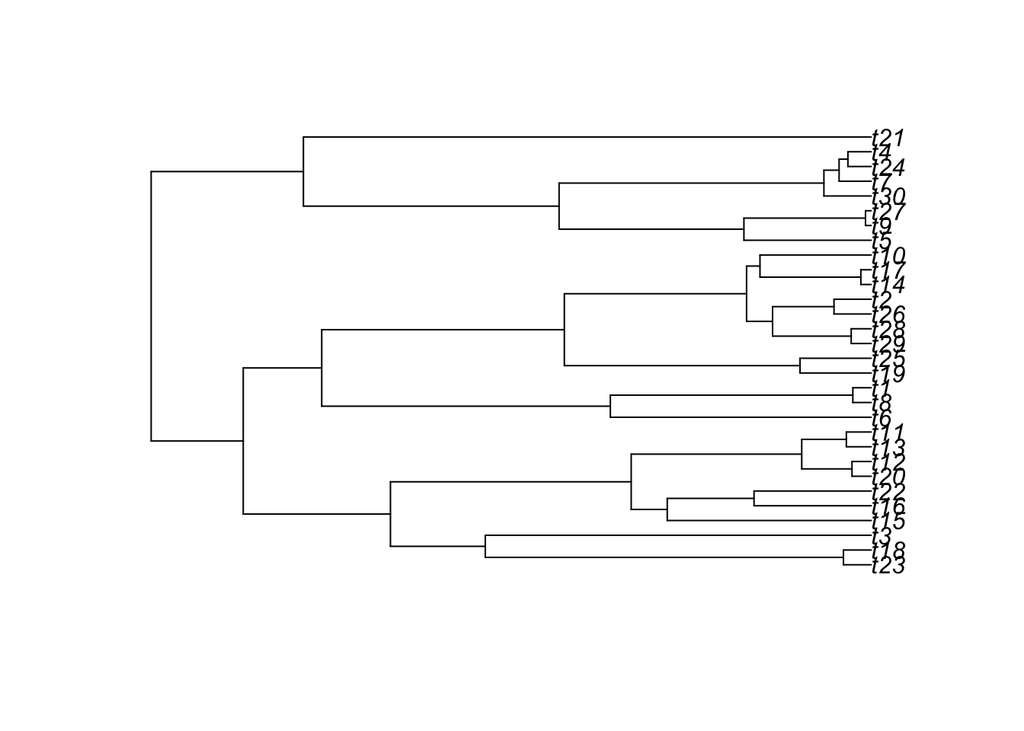

```r
# A simple function that needs functions from the ape library to run
# ape is a library of functions for analysis of evolutionary relationships:
Tree <- function(x){
   #this function creates a plot of a random evolutionary tree
   #of size x
   require(ape)
   tree <- rcoal(x)
   plot(tree)
 }
Tree(30)
```

*Check*: Notice the colours in your script, this is syntax highlighting. Separates:

> 1. comments
> 2. R functions
> 3. numbers
> 4. other things

## Step 7

Once you are done writing your script and you are happy with the commenting. **Save** it in your **working directory** of your project. Give it a meaningful name.

## Step 8

Open your script and run it!

```
File --> Open file --> Search for your working directory then run all or parts of it
```

*Or* you can double click on your R script open it in R studio and run specific parts of it

```
Mac: cmd+return
Windows: ctrl+enter
or pressing Run
```

*Or*

```
setwd("your path") # sets your working directory. You can also do this mannually
source("Script1.R") # source your script, rename accordingly
```

## Step 9

It’s a good idea to create a README text file that describes your project and keep it in the project folder.

This file should describe the overall project and the files in the project folder

### Practice: Create a README text file

```
File --> New File --> Text file

Save it using the name README.txt" in the same directory of your project
```